# Descriptive Graphics in R

## Always plot your data!!

- Descriptive statistics are useful, but should always be complimented with appropriate graphics
- We want to see what the distribution of the sample looks like
- The "shape" of the distribution can often tell us a lot about the population of interest
- A few common graphics we will cover here:
  - boxplot
  - histogram
  - smoothed histogram/nonparametric density

## Boxplots

- A boxplot is obtained by simply drawing a box!
- The top/bottom of the box correspond to the upper/lower quartiles
- A line is then drawn through the median
- Sometimes, the sample mean is also displayed (depends on the software)
- Vertical lines are then drawn from the top and bottom of the box (these are called whiskers)
- These vertical lines extend to the most extreme values in the sample within the range \[ Q_1 - 1.5 \times IQR \quad \textrm{and} \quad Q_3 + 1.5 \times IQR \]
- Observations outside this range are denoted by individual points and are considered as potential outliers!

## Boxplots

```r
# Set up plotting region
par(mfrow = c(1, 2))

# Boxplot for thickness
boxplot(eggshell$thickness, ylab = "Thickness (mm)", col = "red")

# Boxplot for PCB concentration
boxplot(eggshell$pcb, ylab = "PCB concentration (ppb)", col = "blue")
```

## Boxplots

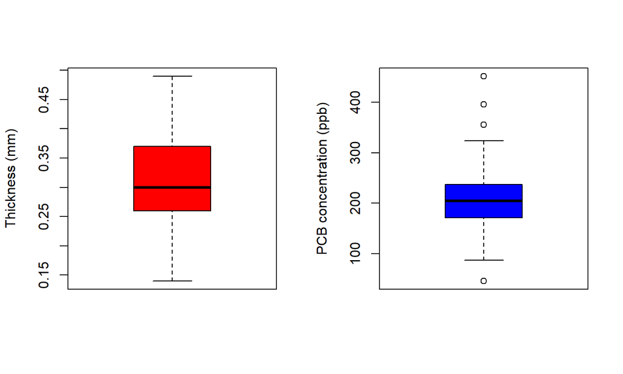

## Histograms

- Another useful graphic for displaying the shape of a distribution is the histogram
- The idea is to divide the observations into bins of equal width
- We then draw rectangles for each bin starting at zero and with a height that corresponds to either the frequency (i.e., the number of observations) in the bin or the relative frequency (i.e., the percentage of observations)

## Histograms

```r
# Set up plotting region
par(mfrow = c(1, 3))

# Default histogram for thickness
hist(eggshell$thickness, main = "", xlab = "Thickness (mm)")

# Too many bins
hist(eggshell$thickness, breaks = 25, freq = FALSE, main = "",
     xlab = "Thickness (mm)")

# Too few bins
hist(eggshell$thickness, breaks = 2, freq = FALSE, main = "",
     xlab = "Thickness (mm)")
```

## Histograms

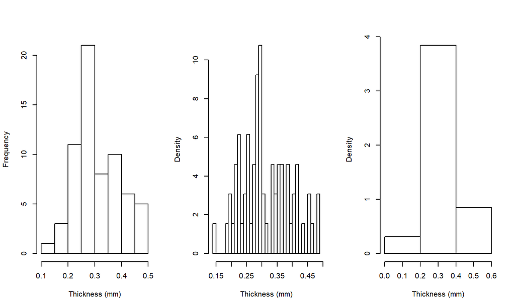

## Distributional shapes

- Determining the number, or equivalently, the width of the bins can be difficult
- If there are too many bins, there will not be enough (if any) in each group
- If there are too few bins, then it will be difficult to capture the shape of the distribution
- If we had an infinite amount of data we could make the histogram as fine as possible by increasing the number of bins
- In this limiting case, the histogram will look like a smooth curve, which we call a density curve

## Distributional shapes

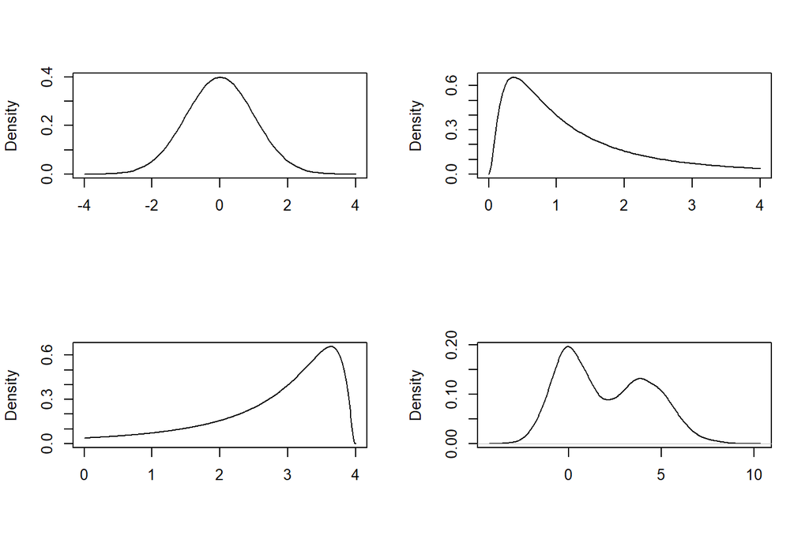